# CHD2 Cortical Brain Organoids Day25 - DEGs overlap with Epilepsy genes

Oliviero Leonardi

January 10, 2025

### Overlap Analysis between Epilepsy genes and DEGs in Day25 Cortical Brain Organoids

**knowledge base:**

- **Epilepsy genes from DisGeNET**
- https://maayanlab.cloud/Harmonizome/gene_set/Epilepsy/DisGeNET+Gene-Disease+Associations

```r
library(GeneOverlap)
library(tidyr)
library(dplyr)
library(ggplot2)
```

## 1. Environment Set Up

```r
for (i in 1:length(params))
  print(paste('Parameter:', names(params)[i], ' - Value:', params[[i]], '- Class:', class(params[[i]])))
```

```
## [1] "Parameter: Dataset  - Value: CHD2_iPSCs_and_organoids_PublicRepo - Class: character"
## [1] "Parameter: DEAList_HT  - Value: /group/testa/Project/CHD2/BulkRNAseq/results/PublicRepo/2.DEA/day25/Output/Savings/day25CbO.DEAList_HT.rds - Class: character"
## [1] "Parameter: DEAList_AR  - Value: /group/testa/Project/CHD2/BulkRNAseq/results/PublicRepo/2.DEA/day25/Output/Savings/day25CbO.DEAList_AR.rds - Class: character"
## [1] "Parameter: GeneSets  - Value: /group/testa/Project/CHD2/BulkRNAseq/data/GeneSets/ - Class: character"
## [1] "Parameter: SavingFolder  - Value: /group/testa/Project/CHD2/BulkRNAseq/results/PublicRepo/7.NDDOverlap/Output/Savings/ - Class: character"
## [1] "Parameter: FiguresFolder  - Value: /group/testa/Project/CHD2/BulkRNAseq/results/PublicRepo/7.NDDOverlap/Output/Figures/ - Class: character"
## [1] "Parameter: FDRthr  - Value: 0.05 - Class: numeric"
## [1] "Parameter: logFCthr  - Value: 1.5 - Class: numeric"
```

## **DEGs are thresholded for Overlap Analysis:**

### **FDR threshold: 0.05**

### **LogFC threshold: 1.5**

```r
logFCthr <- params$logFCthr
FDRthr <- params$FDRthr
```

## 2. Data Upload

### DEA

```r
DEAList_HT <- readRDS(params$DEAList_HT)
DEAList_AR <- readRDS(params$DEAList_AR)

DEAList_HT
```

```
## $dds
## class: DESeqDataSet
## dim: 17781 13
## metadata(1): version
## assays(4): counts mu H cooks
## rownames(17781): TSPAN6 TNMD ... PDCD6-AHRR LNCDAT
## rowData names(51): Gene EnsGene ... deviance maxCooks
## colnames(13): OLE_007 OLE_008 ... OLE_038 OLE_039
## colData names(12): SampleNumber SampleID_GU ... lib.size sizeFactor
##
## $HT
## $HT$res
## log2 fold change (MLE): Genotype HT vs WT
## Wald test p-value: Genotype HT vs WT
## DataFrame with 17781 rows and 6 columns
##                baseMean log2FoldChange     lfcSE      stat    pvalue      padj
##               <numeric>      <numeric> <numeric> <numeric> <numeric> <numeric>
## TSPAN6       1899.95350       0.126856 0.0916115  1.384712 0.1661405  0.416807
## TNMD            1.40474      -0.901158 1.7476042 -0.515653 0.6060966        NA
## DPM1          753.98864      -0.060679 0.0925993 -0.655286 0.5122838  0.757325
## SCYL3         324.26243      -0.123254 0.1218039 -1.011908 0.3115821  0.589861
## C1orf112      606.44497      -0.251886 0.0984460 -2.558627 0.0105086  0.061790
## ...                 ...            ...       ...       ...       ...       ...
## C8orf44       219.88820      0.0784975  0.163767  0.479325 0.6317071  0.834864
## C8orf44-SGK3    6.72668      1.5490628  1.385756  1.117847 0.2636323  0.539837
## NPBWR1          3.20140      0.6146274  1.355148  0.453550 0.6501526        NA
## PDCD6-AHRR     25.30042     -3.7720161  3.456649 -1.091235 0.2751695  0.552450
## LNCDAT          7.67620      1.7878652  0.828398  2.158219 0.0309108  0.138228
##
## $HT$DEGs
##                baseMean log2FoldChange      lfcSE       stat        pvalue         padj
## CFH           26.094947      3.0438007 0.86098471   3.535255  4.073815e-04 4.584685e-03
## ENPP4        218.503431     -0.9487343 0.21605496  -4.391171  1.127417e-05 2.172581e-04
## SEMA3F       718.820104      0.7659644 0.21251021   3.604365  3.129171e-04 3.703258e-03
## HS3ST1       120.628365      3.0725465 0.47583325   6.457192  1.066638e-10 6.740345e-09
## HECW1        127.870718      0.8530832 0.28992535   2.942424  3.256542e-03 2.508466e-02
## KLHL13       292.946998     -0.7107625 0.25499351  -2.787375  5.313699e-03 3.680034e-02
## CYP26B1       64.560436      2.0414678 0.48878717   4.176599  2.959004e-05 4.910949e-04
## SKAP2         67.788433      1.0430165 0.35508420   2.937378  3.310006e-03 2.542631e-02
## COPZ2         30.807971     -1.3257562 0.43865978  -3.022288  2.508717e-03 2.029516e-02
```

[output cut: 365 more lines]

```
## CTSH          74.155863     -1.1046362 0.23612722  1.158029e-07 3.824923e-06
## BMF         1449.952680      0.9945312 0.13813956  3.679141e-14 4.249027e-12
## TRPA1         11.226665      0.9709660 0.85960104  2.224268e-03 1.841206e-02
## CPQ           27.090485     -0.5914849 0.47881376  4.147806e-03 3.037130e-02
## CALB1        737.727904     -2.3041071 0.24338084  7.334321e-23 1.806184e-20
## SFRP1       1447.047551      0.6865710 0.25593851  1.582987e-04 2.068083e-03
## NIPAL2        32.799299     -0.6766169 0.52283634  3.043752e-03 2.383387e-02
## PLAT         345.386781      1.1213317 0.36062456  3.267704e-05 5.333428e-04
## GSDMD         34.351513     -2.9197826 0.39464009  1.775085e-15 2.378046e-13
## OLFM2        334.559507      0.9191335 0.23977827  4.882146e-06 1.046817e-04
## SLC1A6       183.532876      0.9616731 0.26051185  7.364988e-06 1.494959e-04
## KCNN1        195.412604      0.8760081 0.29538848  6.450009e-05 9.567037e-04
## TFPI2        192.192277     -2.3096581 0.38878050  6.071385e-11 3.987114e-09
## DLX5           6.841212      1.3995296 1.64847563  1.686596e-03 1.467207e-02
##  [ reached 'max' / getOption("max.print") -- omitted 1037 rows ]
```

```r
DEAList_AR
```

```
## $dds
## class: DESeqDataSet
## dim: 17781 13
## metadata(1): version
## assays(4): counts mu H cooks
## rownames(17781): TSPAN6 TNMD ... PDCD6-AHRR LNCDAT
## rowData names(51): Gene EnsGene ... deviance maxCooks
## colnames(13): OLE_007 OLE_008 ... OLE_038 OLE_039
## colData names(12): SampleNumber SampleID_GU ... lib.size sizeFactor
##
## $AR
## $AR$res
## log2 fold change (MLE): Genotype AR vs WT
## Wald test p-value: Genotype AR vs WT
## DataFrame with 17781 rows and 6 columns
##                baseMean log2FoldChange     lfcSE       stat     pvalue      padj
##               <numeric>      <numeric> <numeric>  <numeric>  <numeric> <numeric>
## TSPAN6       1899.95350    -0.00321804  0.107759 -0.0298632 0.97617617 0.9969430
## TNMD            1.40474    -2.67322743  2.191542 -1.2197928 0.22254342        NA
## DPM1          753.98864    -0.12588099  0.109614 -1.1484013 0.25080293 0.7661892
## SCYL3         324.26243    -0.10145290  0.143237 -0.7082863 0.47876749 0.8878547
## C1orf112      606.44497    -0.37363020  0.115953 -3.2222548 0.00127186 0.0876281
## ...                 ...            ...       ...        ...        ...       ...
## C8orf44       219.88820       0.164147  0.192447   0.852950   0.393687  0.848049
## C8orf44-SGK3    6.72668       0.282797  1.577018   0.179324   0.857683  0.981561
## NPBWR1          3.20140       0.428658  1.613866   0.265609   0.790540        NA
## PDCD6-AHRR     25.30042      -2.044981  4.131004  -0.495033   0.620577  0.938008
## LNCDAT          7.67620      -0.939696  1.016744  -0.924221   0.355371  0.825025
##
## $AR$DEGs
##                   baseMean log2FoldChange     lfcSE       stat       pvalue         padj
## ZMYND10           57.19480      1.3624567 0.3892638   3.500086 4.651089e-04 4.624891e-02
## CACNA1G          822.06192      0.7856551 0.2171074   3.618739 2.960425e-04 3.493302e-02
## NRXN3            125.92310      1.5316628 0.3828391   4.000800 6.312865e-05 1.247513e-02
## DSG2             537.93484      1.3351256 0.3360632   3.972840 7.102070e-05 1.354513e-02
## UBE2T            701.97049     -1.0105319 0.1132986  -8.919190 4.697111e-19 1.284034e-15
## OSBPL6           248.89844     -0.6141677 0.1721876  -3.566851 3.612962e-04 4.027025e-02
## ZNF506           590.46712     -1.0754446 0.1436865  -7.484663 7.173113e-14 1.593125e-10
## ZNF671           204.82774     -1.0215515 0.2865220  -3.565351 3.633701e-04 4.027025e-02
## HSD17B14         169.46894      1.0153134 0.2645589   3.837760 1.241619e-04 2.036503e-02
```

[output cut: 188 more lines]

```
## SILC1            263.50428     -1.1546873 0.6259759 2.526341e-05 6.184634e-03
## MCIDAS            15.18667      2.7491262 1.5254740 1.076408e-05 3.152722e-03
## TNFRSF6B          22.78767     -1.2092311 1.7232238 1.306657e-04 2.041123e-02
## ZNF585B          278.29547     -1.1431862 0.1709485 2.050933e-12 2.402815e-09
## FZD10-AS1        332.37868     -5.3834598 0.8492106 4.709741e-11 5.149945e-08
## PURPL            103.46331      1.3073952 0.4144333 2.951331e-06 1.210193e-03
## PCDHA3            27.07316     -2.3426023 1.2403810 9.264873e-06 2.762954e-03
## BLOC1S5-TXNDC5    19.56246      1.3727224 2.0578874 1.261048e-04 2.041123e-02
## TXNIP           9764.81344     -0.6922104 0.3288879 4.065628e-05 8.891257e-03
## ZNF790-AS1       123.79130     -0.8053930 0.3135949 1.859682e-05 5.083751e-03
## MIR924HG          35.75603     -4.5591386 0.8042174 3.097868e-09 2.822846e-06
## LHX1              43.69816      3.2488715 1.2653518 3.452545e-06 1.381186e-03
## LHX1-DT           13.31591      0.6569610 1.3712051 3.553003e-04 3.991532e-02
## ZNF229            44.84718     -1.6924821 1.5933962 4.810762e-05 9.988115e-03
## BLACAT1         1298.36493      1.0242981 0.3576873 9.220814e-06 2.762954e-03
```

```r
# check for genes with duplicated name
table(duplicated(row.names(DEAList_HT)))
## < table of extent 0 >
if(sum(duplicated(row.names(DEAList_HT$HT$res))) > 0){
  stop('Genes with duplicated symbol in DEA results')
}

table(duplicated(row.names(DEAList_HT)))
## < table of extent 0 >
if(sum(duplicated(row.names(DEAList_HT$HT$DEGs))) > 0){
  stop('DEGs with duplicated symbol')
}

# check for genes with duplicated name
table(duplicated(row.names(DEAList_AR)))
## < table of extent 0 >
if(sum(duplicated(row.names(DEAList_AR$HT$res))) > 0){
  stop('Genes with duplicated symbol in DEA results')
}

table(duplicated(row.names(DEAList_AR)))
## < table of extent 0 >
if(sum(duplicated(row.names(DEAList_AR$HT$DEGs))) > 0){
  stop('DEGs with duplicated symbol')
}
```

## 3. Data load: gene-phenotype knowledge bases

```r
Epilepsy_genes <- read.table(paste0(params$GeneSets, 'epilepsy_genes.txt'))
colnames(Epilepsy_genes) <- 'Symbol'
```

## 4. Definition of Gene Universe and Modules

Gene Universe is defined as the genes that have been used for the generation of gene modules.

### 4.1 Gene Universe

Define the universe of shared genes between the two networks that will be used for the overlap analysis.

```r
UniverseHT <- rownames(DEAList_HT$dds) # %>% unique() not necessary because checked above absence of duplicates
UniverseAR <- rownames(DEAList_AR$dds) # %>% unique() not necessary because checked above absence of duplicates

if (!identical(UniverseAR, UniverseHT)) {
  print('Gene universes are not identical. Proceeding to compute union')
  Universe <- union(UniverseAR, UniverseHT)
}

if (identical(UniverseAR, UniverseHT)) {
  print('Gene universes are identical. Storing union as Universe')
  Universe <- union(UniverseAR, UniverseHT)
}
```

```
## [1] "Gene universes are identical. Storing union as Universe"
```

```r
length(Universe)
```

```
## [1] 17781
```

17781 genes have module assignment and will be used for the overlap analysis.

### 4.2 DEGs list

Retrieve for each comparison the selected DEGs and organize in a list.

```r
DEA <- list()

#DEA$DEGs_HT = row.names(DEAList_HT$HT$DEGs)[row.names(DEAList_HT$HT$DEGs) %in% Universe]
#table(duplicated(DEA$HT))

#DEA$DEGs_AR <- row.names(DEAList_AR$AR$DEGs)[row.names(DEAList_AR$AR$DEGs) %in% Universe]
#table(duplicated(DEA$AR))

# More stringent filtering
DEA$DEGs_HT <-  row.names(data.frame(DEAList_HT$HT$res) %>% dplyr::filter(abs(DEAList_HT$HT$res$log2FoldChange) > log2(logFCthr), DEAList_HT$HT$res$padj < FDRthr)) #manual filtering of results object to get DEGs

DEA$DEGs_AR <-  row.names(data.frame(DEAList_AR$AR$res) %>% dplyr::filter(abs(DEAList_AR$AR$res$log2FoldChange) > log2(logFCthr), DEAList_AR$AR$res$padj < FDRthr)) #manual filtering of results object to get DEGs


length(DEA$DEGs_HT)
```

```
## [1] 1511
```

```r
length(DEA$DEGs_AR)
```

```
## [1] 111
```

## 5. Test for overlap enrichment

For each disease, I select the genes that are found in the universe. Each gene is included only once.

```r
GeneVect <- list()

GeneVect$Epilepsy <- unique(Epilepsy_genes$Symbol)[unique(Epilepsy_genes$Symbol) %in% Universe]
```

### 5.2 Overlap Contingency Table

```r
OvObj <- newGOM(DEA, GeneVect, genome.size=length(Universe))
print(OvObj)
## A GeneOverlapMatrix object:
## ###### Intersection ######
##         Epilepsy
## DEGs_HT      152
## DEGs_AR       13
## ###### P-value ######
##             Epilepsy
## DEGs_HT 1.057364e-07
## DEGs_AR 3.287480e-02
## ###### Odds Ratio ######
##         Epilepsy
## DEGs_HT 1.653126
## DEGs_AR 1.870762
## ###### Jaccard Index ######
##           Epilepsy
## DEGs_HT 0.05979544
## DEGs_AR 0.01014832
```

#### Intersection Numbers

```r
getMatrix(OvObj, name='intersection')
```

```
##         Epilepsy
## DEGs_HT      152
## DEGs_AR       13
```

#### Intersection PValues

```r
getMatrix(OvObj, name='pval')
```

```
##             Epilepsy
## DEGs_HT 1.057364e-07
## DEGs_AR 3.287480e-02
```

#### Intersection Odds Ratios

```r
getMatrix(OvObj, name='odds.ratio')
```

```
##         Epilepsy
## DEGs_HT 1.653126
## DEGs_AR 1.870762
```

## 6. Visualize overlap enrichment

### 6.1 DotPlot

- Data are re-organized for visualization
- Only OR > 1 are kept for visualization
- Numbers are visualized for all categories passing the OR filter
- Coloured dot is shown only for categories passing a pvalue threshold of 0.05

```r
OR <- data.frame(getMatrix(OvObj, name='odds.ratio'))
OR$Module <- row.names(OR)
OR <- gather(OR, 'KBase', 'OR', -Module)

PVAL <- data.frame(getMatrix(OvObj, name='pval'))
PVAL$Module <- row.names(PVAL)
PVAL <- gather(PVAL, 'KBase', 'PVal', -Module)

NUM <- data.frame(getMatrix(OvObj, name='intersection'))
NUM$Module <- row.names(NUM)
NUM <- gather(NUM, 'KBase', 'Numbers', -Module)


if(! identical(OR$Module, PVAL$Module)){
  stop('Inconsistency')
}
if(! identical(OR$Module, NUM$Module)){
  stop('Inconsistency')
}
if(! identical(OR$KBase, NUM$KBase)){
  stop('Inconsistency')
}
if(! identical(OR$KBase, NUM$KBase)){
  stop('Inconsistency')
}


Res <- mutate(OR, Pval=PVAL$PVal) %>% mutate(Numbers=NUM$Numbers)

OR
NUM
```

[output not shown]

```r
ResSel <- dplyr::filter(Res, OR > 1)

max(ResSel$OR)
```

```
## [1] 1.870762
```

```r
max(-log10(ResSel$Pval))
```

```
## [1] 6.975775
```

```r
ResSel %>% dplyr::filter(Pval < 0.05)
```

[output not shown]

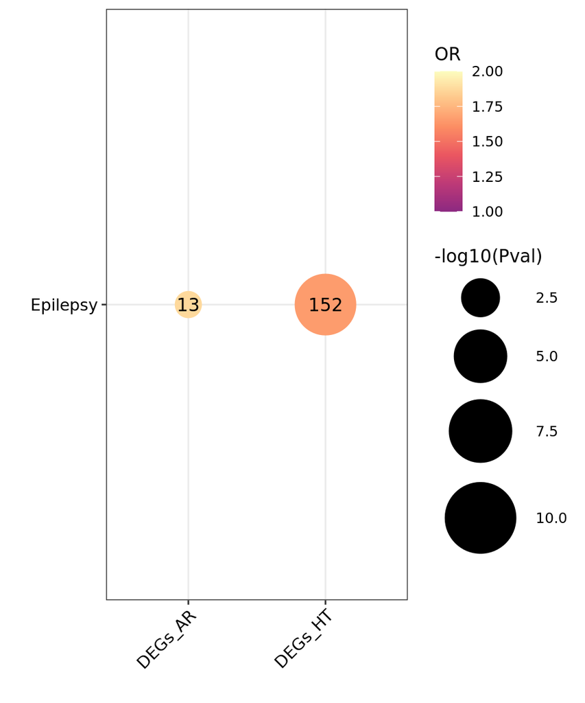

```r
cols <- viridis::cividis(100)[20:100]

Dot <- ggplot(ResSel, aes(Module, KBase, label=Numbers)) +
  geom_point(aes(size=-log10(Pval), col=OR)) +
  geom_text() +
  scale_size_continuous(range=c(5, 20), limits=c(-log10(0.05), 10)) +
  scale_color_viridis_c(limits=c(1, 2), begin=0.4, option = 'A') + xlab('') + ylab('') +
  theme_bw() +
  theme(axis.text.x = element_text(angle = 45, vjust = 1, hjust=1)) +
  theme(axis.text = element_text(size=10, color='black'))

Dot
```

```r
ggsave(Dot, filename=paste0(params$FiguresFolder, 'KB_Epilepsy_day25.pdf'), width=6.5, height=6.5)
```

## 7. Overlapping gene identity

Check gene identity for each significant overlap.

### Heterozygous

- For **Epilepsy 152 overlapping genes**: ABCB1, ABCC2, ADARB1, ADCY9, ADGRV1, AFF2, APBA2, AQP1, AQP4, ASCL1, ATP1A2, AZGP1, BCL11A, BDNF, BMP4, CACNA1A, CACNA1C, CACNA1G, CACNA1H, CALB1, CAT, CCL2, CD68, CDKL5, CFH, CHRFAM7A, CHRNA4, CHRNB2, CISH, CNR1, CNTN2, COL18A1, COL2A1, COMT, CRIP1, CRISPLD2, CXCL12, CYP1A1, DLX1, DLX2, DSCAM, ECM1, EEF1A2, EGR1, ELN, ENO2, EPHA4, FBLIM1, FN1, FOXD3, FOXG1, FOXO4, FOXP2, FRRS1L, GABRB2, GABRB3, GAD2, GALR1, GDNF, GJA1, GNAO1, GREM1, GRIN1, GRM1, GRM2, GRM7, HAP1, HCN2, HECW2, HLA-A, HLA-B, HSPG2, IL2RB, KCNC4, KCNH1, KCNK9, KLHL29, LAMB1, LGI1, LGI4, MAPK10, MDM2, MEF2C, MICA, MLLT3, MMP2, MYD88, NGFR, NID1, NIPA1, NOS3, NRP2, NTNG2, NTRK1, OLFML3, OPRD1, OPRK1, PAG1, PAM, PANX2, PDYN, PEX5L, PHOX2A, PITX2, PLAT, PLCB1, PLP1, PMP22, PNPO, POMC, PRDM8, PRICKLE1, PRICKLE2, PRKCA, PRKCD, PRNP, PTGS1, PTGS2, PTPRZ1, RBFOX2, RBFOX3, RUNX2, S100A10, S100B, SCN2B, SCN3A, SCN7A, SEMA3C, SEMA7A, SH3GL2, SHROOM4, SLC13A5, SLC2A1, SLC2A3, SLC46A1, SLC4A10, SLC6A11, SLC6A3, SLC9A3R2, SLCO1A2, SMOX, SNCA, SORBS1, SOX11, ST8SIA2, SYN1, SYNPO, SYP, TAP1, TUBB2A, UCP2, VCAM1

#### Epilpesy

```r
overlapEpilepsy_1 <- paste0(sort(intersect(DEA$DEGs_HT, GeneVect$Epilepsy)))
print('Genes present in the overlap for Epilpesy:')
```

```
## [1] "Genes present in the overlap for Epilpesy:"
```

```r
DT::datatable(as.data.frame(overlapEpilepsy_1), class = "hover", colnames = "",
              escape = FALSE, caption = "Heterozygous (Epilepsy)",
              options = list(autoWidth = TRUE, dom = "Bfrtip"))
```

| 1 | ABCB1 |
| --- | --- |
| 2 | ABCC2 |
| 3 | ADARB1 |
| 4 | ADCY9 |
| 5 | ADGRV1 |
| 6 | AFF2 |
| 7 | APBA2 |
| 8 | AQP1 |
| 9 | AQP4 |
| 10 | ASCL1 |

[output cut: 142 more lines]

### Ancestral

- For **Epilepsy 13 overlapping genes**: ABHD6, APOE, BNIP3, CACNA1G, CLU, CNTNAP2, EGR2, GRIA1, MT-CYB, NRXN3, SOX11, SPAG8, TFCP2

#### Epilepsy

```r
overlapEpilepsy_2 <- paste0(sort(intersect(DEA$DEGs_AR, GeneVect$Epilepsy)))
print('Genes present in the overlap for Epilepsy:')
```

```
## [1] "Genes present in the overlap for Epilepsy:"
```

```r
DT::datatable(as.data.frame(overlapEpilepsy_2), class = "hover", colnames = "",
              escape = FALSE, caption = "Ancestral (Epilepsy)",
              options = list(autoWidth = TRUE, dom = "Bfrtip"))
```

| 1 | ABHD6 |
| --- | --- |
| 2 | APOE |
| 3 | BNIP3 |
| 4 | CACNA1G |
| 5 | CLU |
| 6 | CNTNAP2 |
| 7 | EGR2 |
| 8 | GRIA1 |
| 9 | MT-CYB |
| 10 | NRXN3 |

[output cut: 3 more lines]

## 8. Savings

```r
saveRDS(Res, paste0(params$SavingFolder, 'day25_EpilepsyOverlapResults.rds'))
```

```r
SessionInfo <- sessionInfo()
Date <- date()
save.image(paste0(params$SavingFolder, 'KB_Epilepsy_day25.RData'))
```

```r
Date
```

```
## [1] "Fri Jan 10 21:08:19 2025"
```

```r
SessionInfo
```